# pSIMS Tutorial

## Defining the tags

This tutorial is only for the cases in which the user intend to run a rotation of crops in APSIM pSIMS and using `pSIMSSiteMaker` Package. In that case, make sure that you have the latest version of `pysims`. You can find the latest version here : [Link to the repository](https://github.com/AgronomicForecastingLab).

### Planting and Harvesting

The new version of `pysims` is able to handle as series of events entered in the Campaign.json and convert them into operations in APSIM ([APSIM Operations](https://www.apsim.info/documentation/model-documentation/infrastructure-and-management-documentation/operations/)). Using this feature we can introduce a series of planting and harvesting operations for different crops. The json tags look like following :

```json
"management":{
      "events": [
      {
      "date": "20180504",
      "crid":"maize",
      "event": "planting",
      "plpop": "8.4",
      "pldp": "40",
      "plrs" : "762",
      "cul_id": "?"
      },
      {
      "date":"20180610",
      "event":"fertilizer",
      "feamn": "200",
      "fedep": "200"
      },
      {
      "event": "harvest",
      "crid":"maize",
       "date": "20181120"
      },
      {
      "date": "20190504",
      "crid":"soybean",
      "event": "planting",
      "plpop": "8.4",
      "pldp": "40",
      "plrs" : "762",
      "cul_id": "MG_8"
      },
      {
      "event": "harvest",
      "crid":"soybean",
       "date": "20191120"
      }
      ]
  }
```

There are few important notes that needs to be taken into account after adding the management tag in your campaign.json.

**1)** Your `crop_name` tag on the top of the `campaign.json` should include both crops as following :

```json
 "crop_name": ["Maize","Soybean"]
```

This tag needs to be used in conjunction with the APSIM template attached to this tutorial. Given this tag and the apsim template, pysims will create a crop module in your simulation for each crop specified.

**2)** In our `campaign.json` we keep the tag for all the other operations such as fertilization and etc but each need to have a tag to specify to what crop this operation will apply. Look at the example below :

```json
    "fertilizer": {
    "fert_criteria": "100",
    "fert_critical": "90",
    "type_auto": "NO3_N",
    "initial_amount": "200",
    "type": "NH4NO3",
    "days_after_sowing": "45",
    "subsequent_amount": "0",
    "depth": "40",
    "crop":"Maize"
    }
```

**3)** In psims param files, a single cultivar template should be provided for each crop with the same order they were defined in `crop_name` as follows:

```yaml
cultivarfile: /pysims/data/SiteMN/Maize_template.xml,/pysims/data/SiteMN/Soybean_template.xml
```

**4)** We only can specify randomized cultivar parameters for **only** the first crop (maize in this case). In this case the `cul_id` in the management tag will be left as `?`. This will let `pysims` know that this cultivar needs to be replaced with the new custom cultivar generated (`CC0001` and etc). However for the second crop (soybean in this case) cultivar needs to be provided.

### Fertilizer

Fertilizer operation could be also added using the below tags:

```json
      {
      "date":"20180610",
      "event":"fertilizer",
      "feamn": "200",
      "fedep": "200"
      }
```

In the above tag, `feamn` represent the amount of fertilizer in (Kg/ha) and `fedep` represents the depth in (mm)

## Putting them all together

In `pSIMSSiteMaker` package, we have developed functions to handle creating the management tags. We can use `Mangment_campaign_json_maker` function to create planting, harvesting and fertilizer operations all at once using this function. If no fertilization is needed all the arguments should be left unspecified. Below is an example of full code for creating a rotation simulation in psims :

```r
library(pSIMSSiteMaker)
#Delete previous versions of the run if exists
unlink('/mnt/iccp_storage/hamzed/tmp/Rotation', recursive = TRUE)

host <-
  list(name = 'cc-login.campuscluster.illinois.edu',
       user = 'hamzed',
       tunnel = '~/tunnel/tunnel',
       from='/mnt/iccp_storage/hamzed/tmp/Rotation',
       to='/projects/aces/hamzed/psims/Data/sims')

#Modifying the params
tmp_param <- Read_param_template()
tmp_param$ref_year <- 2018L
tmp_param$num_years <- 2
tmp_param$scen_years <- 2
tmp_param$scens <- 5
tmp_param$tappinp$cultivarfile <- c("Maize_template.xml","Soybean_template.xml")

#Modifying the campaign json file
tmp_camp <- Read_Campaign_template()
tmp_camp$reporting_frequency <- "end_day"

# Point 1
tmp_camp$crop_name <- c("maize", "soybean")

# Point2
tmp_camp$fertilizer$crop <- "Maize"
tmp_camp$planting$crop <- "Maize"
tmp_camp$initial_condition$residue_type <- "Maize"

#-----Creating the operations for each crop separately
First_crop <- Mangment_campaign_json_maker(
  PlantingDate=as.Date("2018-05-03"),
  HarvestDate=as.Date("2018-11-03"),
  Crop = "maize",
  Cultivar = "?", # psims will ensemblize the cultivar
  Population="8.4",
  Depth="40",
  RowSpacing="762",
  fert_date = as.Date("2018-07-03"),
  fertamnt= "200",
  fertdepth= "300"
)

second_crop <- Mangment_campaign_json_maker(
  PlantingDate=as.Date("2019-05-03"),
  HarvestDate=as.Date("2019-11-03"),
  Crop = "soybean",
  Cultivar = "MG_8", # cultivar need to be specified here. This needs to be tested but maybe we can use the number system in psims (date_1, date_2) to ensemblize all the cultiavrs
  Population="8.4",
  Depth="40",
  RowSpacing="762"
)

tmp_camp$management$events <-  c(First_crop, second_crop)


pSIMS_Site_Make(
  dirname = "/mnt/iccp_storage/hamzed/tmp",
  Project_name = "Rotation",
  Lat = 40.04,
  Lon = -88.5,
  Campaign_Path = 'Campaign.nc4',
  APSIM_Template_Path = "template.apsim",
  Param_template_Obj = tmp_param,
  Campaign_json_Obj = tmp_camp,
  APSIM_Cultivar_Path = c("Maize_template.xml", "Soybean_template.xml"),
  # Point 3
  host = host,
  Bash_control = list(
    pSIMS_Data_Path = "/pysims/data/sims",
    # No need to edit this
    pSIMS_server_Path = "/projects/aces/hamzed/psims/Data",
    pSIMS_Sing_Image = "/projects/aces/mkivi2/psims/Bash/apsim_psims_image/custom_psims_full.img"
  )
)
```

As it was explained before we can bring back the outputs from the campus cluster using the following code :

```r
remote.copy.from(host=host,
                 src='/projects/aces/hamzed/psims/Data/sims/Rotation/5996',
                 dst='/mnt/iccp_storage/hamzed/tmp/Rotation/Results',
                 delete = TRUE)
```

After bringing the model outputs we can read them in :

```r
Model.results <- list.files("/mnt/iccp_storage/hamzed/tmp/Rotation/Results",".out", recursive = TRUE, full.names = TRUE) %>%
  purrr::map_dfr(function(.x){
    print(.x)

    hdr <-     as.character(sapply(as.vector(read.table(file = .x,
        header = FALSE, sep = "", nrows = 1, skip = 2)[1, ]),
        FUN = function(x) x[[1]]))

     read.table(file = .x, header = FALSE,  sep = "", skip = 4) %>%
      `colnames<-`(c(hdr)) %>%
       dplyr::mutate(Date=as.Date(Date, format = "%d/%m/%Y"),
              name=basename(.x))

  })
```

```
## [1] "/mnt/iccp_storage/hamzed/tmp/Rotation/Results/5996/10980/Generic.out"
## [1] "/mnt/iccp_storage/hamzed/tmp/Rotation/Results/5996/10980/Generic1.out"
## [1] "/mnt/iccp_storage/hamzed/tmp/Rotation/Results/5996/10980/Generic2.out"
## [1] "/mnt/iccp_storage/hamzed/tmp/Rotation/Results/5996/10980/Generic3.out"
## [1] "/mnt/iccp_storage/hamzed/tmp/Rotation/Results/5996/10980/Generic4.out"
```

Here is the first few lines of the output :

```r
head(Model.results)
```

```
##         Date paddock.soybean.biomass paddock.maize.biomass
## 1 2018-01-01                       0                     0
## 2 2018-01-02                       0                     0
## 3 2018-01-03                       0                     0
## 4 2018-01-04                       0                     0
## 5 2018-01-05                       0                     0
## 6 2018-01-06                       0                     0
##   paddock.soybean.yield paddock.maize.yield   st(1)   st(2)   st(3)   st(4)
## 1                     0                   0 -21.327 -20.788 -19.921 -18.534
## 2                     0                   0 -20.134 -19.615 -18.780 -17.444
## 3                     0                   0 -17.825 -17.342 -16.565 -15.322
## 4                     0                   0 -16.110 -15.655 -14.923 -13.749
## 5                     0                   0 -14.434 -14.006 -13.318 -12.212
## 6                     0                   0 -13.286 -12.877 -12.220 -11.164
##     st(5)   st(6)  st(7)  st(8) sws(1) sws(2) sws(3) sws(4) sws(5) sws(6)
## 1 -16.329 -12.949 -8.034 -1.574  0.262  0.262  0.268  0.268  0.293  0.294
## 2 -15.318 -12.056 -7.305 -1.047  0.261  0.263  0.268  0.268  0.293  0.294
## 3 -13.340 -10.293 -5.846  0.025  0.263  0.263  0.267  0.269  0.293  0.294
## 4 -11.877  -8.993 -4.776  0.806  0.263  0.263  0.267  0.269  0.293  0.294
## 5 -10.447  -7.725 -3.731  1.567  0.263  0.263  0.267  0.269  0.292  0.294
## 6  -9.476  -6.867 -3.033  2.069  0.263  0.264  0.267  0.269  0.292  0.294
##   sws(7) sws(8)        name
## 1  0.231  0.231 Generic.out
## 2  0.231  0.231 Generic.out
## 3  0.231  0.231 Generic.out
## 4  0.231  0.231 Generic.out
## 5  0.231  0.231 Generic.out
## 6  0.231  0.231 Generic.out
```

Finally we can visualize the output to make sure we have reasonable outcomes:

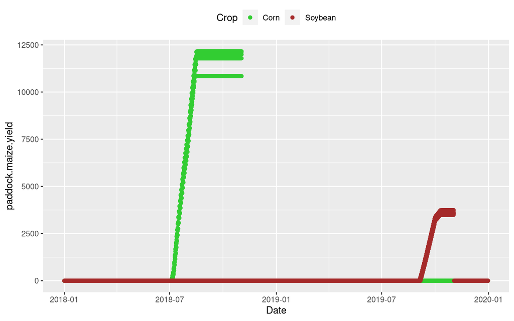

```r
library(ggplot2)

Model.results %>%
  ggplot(aes(Date))+
  geom_point(aes(y=paddock.maize.yield, color="Corn"))+
  geom_point(aes(y=paddock.soybean.yield, color="Soybean"))+
  scale_color_manual(values=c("limegreen", "brown"), name="Crop")+
  theme(legend.position = "top")
```

## Retrieving historic crop rotation from CropScape

```r
pSIMSSiteMaker::historic_rotation_CropScape(
         x=c(-88.50118, -88.49830, -88.54710, -88.54996),
         y=c(40.29701, 40.32438, 40.32727, 40.29990),
         years=c(2015:2020)
)
```

```
## $`2015`
## $`2015`[[1]]
## [1] "Corn"
##
## $`2015`[[2]]
##   alu  oun                     ategor     olo  creag
## 1   1 6937                       Corn #FFD400 1542.8
## 2   5 6198                   Soybeans #267300 1378.4
## 3  36    1                    Alfalfa #FFA8E3    0.2
## 4  61    1       Fallow/Idle Cropland #BFBF7A    0.2
## 5 121  433       Developed/Open Space #9C9C9C   96.3
## 6 122  303    Developed/Low Intensity #9C9C9C   67.4
## 7 123   10 Developed/Medium Intensity #9C9C9C    2.2
## 8 141   15           Deciduous Forest #95CE93    3.3
## 9 176   76              Grass/Pasture #E9FFBE   16.9
##
##
## $`2016`
## $`2016`[[1]]
## [1] "Soybeans"
##
## $`2016`[[2]]
##   alu  oun                     ategor     olo  creag
## 1   1 5935                       Corn #FFD400 1319.9
## 2   5 7180                   Soybeans #267300 1596.8
## 3  24   19               Winter Wheat #A87000    4.2
## 4 121  431       Developed/Open Space #9C9C9C   95.9
## 5 122  309    Developed/Low Intensity #9C9C9C   68.7
## 6 123    9 Developed/Medium Intensity #9C9C9C      2
## 7 131    1                     Barren #CCBFA3    0.2
## 8 141   15           Deciduous Forest #95CE93    3.3
## 9 176   75              Grass/Pasture #E9FFBE   16.7
##
##
## $`2017`
## $`2017`[[1]]
## [1] "Corn"
##
## $`2017`[[2]]
##   alu  oun                     ategor     olo  creag
```

[output cut: 52 more lines]

```
## [1] "Soybeans"
##
## $`2020`[[2]]
##    alu  oun                     ategor     olo  creag
## 1    1 5922                       Corn #FFD400   1317
## 2    5 7546                   Soybeans #267300 1678.2
## 3   26    8   Dbl Crop WinWht/Soybeans #737300    1.8
## 4  111    1                 Open Water #4D70A3    0.2
## 5  121  171       Developed/Open Space #9C9C9C     38
## 6  122  233    Developed/Low Intensity #9C9C9C   51.8
## 7  123   11 Developed/Medium Intensity #9C9C9C    2.4
## 8  131    2                     Barren #CCBFA3    0.4
## 9  141   16           Deciduous Forest #95CE93    3.6
## 10 143    9               Mixed Forest #95CE93      2
## 11 176   55              Grass/Pasture #E9FFBE   12.2
```